# 1810055 刘汉青

## 数据读取和包的载入

```r
data<-read.csv('D:/应用统计专题/作业/tvdata.csv')
summary(data)
options(repr.plot.width=20, repr.plot.height=8)
library('ggplot2')
library('car')
```

```
     名称               类型                集数           豆瓣评分
 Length:801         Length:801         Min.   :  1.00   Min.   :2.800
 Class :character   Class :character   1st Qu.: 10.00   1st Qu.:7.100
 Mode  :character   Mode  :character   Median : 12.00   Median :8.200
                                       Mean   : 17.02   Mean   :7.854
                                       3rd Qu.: 21.00   3rd Qu.:8.900
                                       Max.   :180.00   Max.   :9.800
    评价人数        单集片长             语言
 Min.   :    39   Length:801         Length:801
 1st Qu.:   609   Class :character   Class :character
 Median :  2719   Mode  :character   Mode  :character
 Mean   : 13499
 3rd Qu.: 13183
 Max.   :195955
```

# 1. 描述性分析&数据预处理

## (2)单集片长

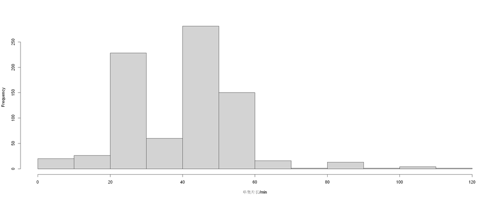

```r
data[518,'单集片长']=0
hist(as.numeric(data$单集片长),xlab='单集片长/min',main='')
```

一方面，不认为单集长度上的细微差别存在真正意义上的不同，而另一方面，可以从histogram中看到明显的分组特征。因此，我将单集长度为0-25min的电视剧赋值为0，25min-45min的赋值为1，45min以上的赋值为2。

```r
len<-as.numeric(data$单集片长)
len[which(len<25)]=0
len[which(len>=25&len<45)]=1
len[which(len>=45)]=2
```

## (3)剧集总时长

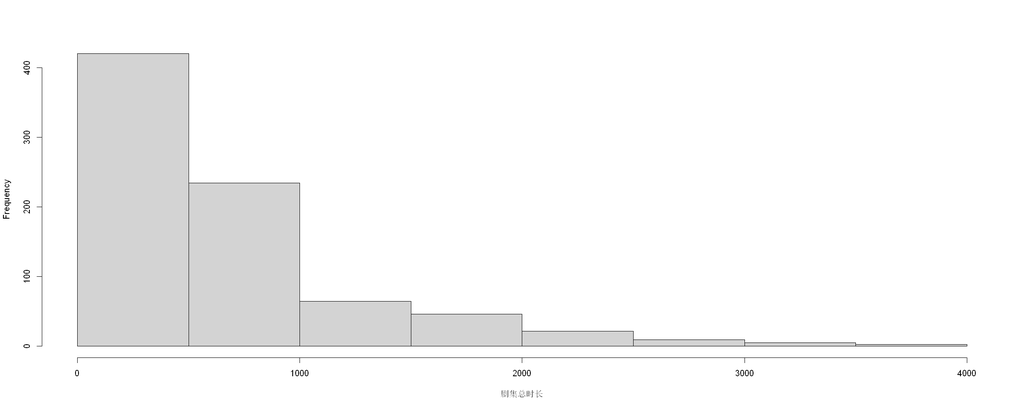

```r
data$总时长<-as.numeric(data$单集片长)*as.numeric(data$集数)
hist(data$总时长,xlab='剧集总时长',main='')
```

## (4)评价人数

```
   Min. 1st Qu.  Median    Mean 3rd Qu.    Max.
     39     609    2719   13499   13183  195955
```

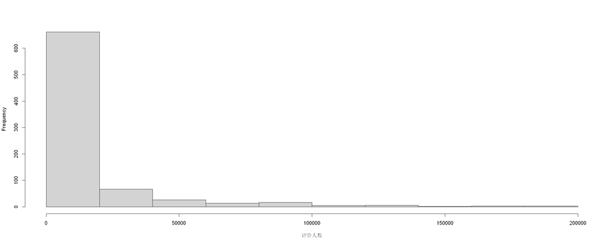

```r
options(repr.plot.width=20, repr.plot.height=8)
hist(data$评价人数,xlab='评价人数',main='')
summary(data$评价人数)
```

- 观察histogram发现拥有大量评价的影片数量非常少，这可能影响回归分析的结果。因此在回归分析中使用的数据da取用了评价人数小于3/4位数，即13183人次的剧集。调整后分布如下：

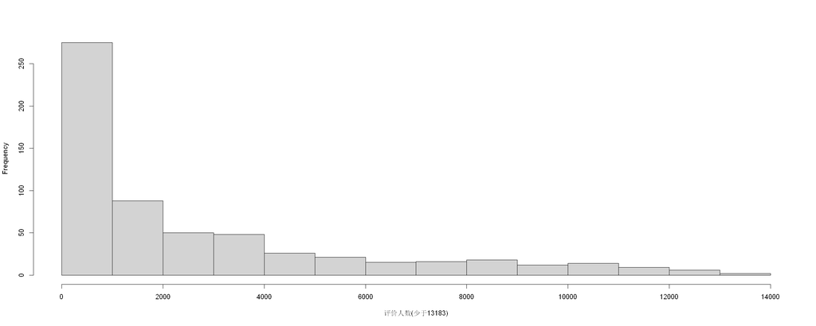

```r
hist(data$评价人数[which(data$评价人数<13183)],xlab='评价人数(少于13183)',main='')
```

```r
da<-data[which(data$评价人数<13183),]
```

## (5)类型与语言

- 类型和语言都作为factor处理

# 2.聚类分析(影片类型)

```r
library('ggplot2')
```

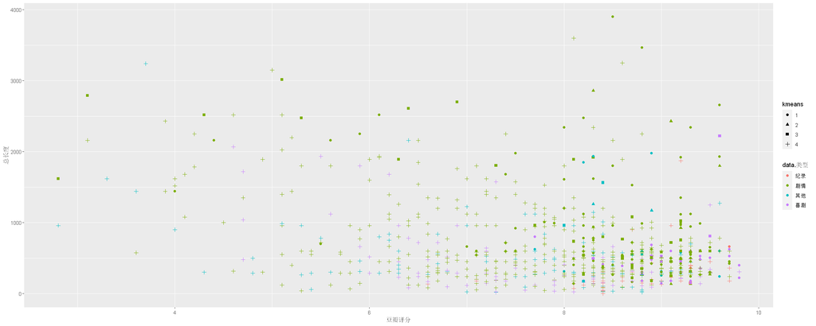

```r
d<-data.frame(data$豆瓣评分,data$总时长,data$评价人数)
which(is.na(d))
km<-kmeans(d,4)
#原数据中共分为4类
k=t(km[1])
d$kmeans<-as.factor(unlist(k))
dt<-data.frame(d,data$类型)
ggplot(data=dt, aes(data.豆瓣评分,data.总时长,color=data.类型,shape=kmeans))+geom_point(size=2)+
  labs(x='豆瓣评分',y='总长度')
```

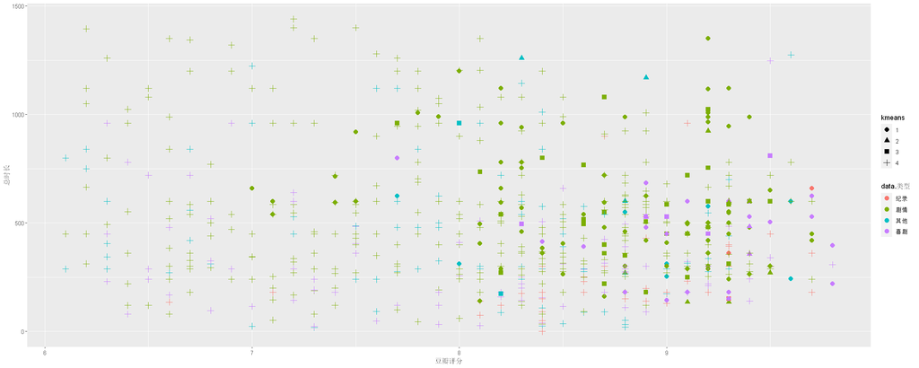

```r
dtt=dt[which((dt$data.豆瓣评分>6)&(dt$data.总时长<1500)),]
ggplot(data=dtt, aes(data.豆瓣评分,data.总时长,color=data.类型,shape=kmeans))+geom_point(size=3)+
  labs(x='豆瓣评分',y='总时长')
```

```r
summary(as.factor(data$类型))
summary(as.factor(unlist(k)))
```

**纪录**

41

**剧情**

503

**其他**

127

**喜剧**

130

**1**

134

**2**

18

**3**

51

**4**

598

- 认为在聚类结果中，1暗示喜剧，2暗示纪录，3暗示其他，4暗示剧情或1暗示其他，2暗示纪录，3暗示喜剧，4暗示剧情
- 下面计算正确率

```r
ac1<-(sum(dt[which(dt$data.类型=='喜剧'),'kmeans']==1)+sum(dt[which(dt$data.类型=='纪录'),'kmeans']==2)+sum(dt[which(dt$data.类型=='其他'),'kmeans']==3)+sum(dt[which(dt$data.类型=='剧情'),'kmeans']==4))/801
ac2<-(sum(dt[which(dt$data.类型=='其他'),'kmeans']==1)+sum(dt[which(dt$data.类型=='纪录'),'kmeans']==2)+sum(dt[which(dt$data.类型=='喜剧'),'kmeans']==3)+sum(dt[which(dt$data.类型=='剧情'),'kmeans']==4))/801
print(max(ac1,ac2))
```

```
[1] 0.4856429
```

- 正确率约为48.6%，聚类结果较差。当然，数据集中提供的信息显然不足以区分影视剧的类型，因此较低的正确率是可以理解的。

# 3. 回归分析

```r
da<-data[which(data$评价人数<13183),]
```

## (1)单因素分析

```r
l<-lm(da$豆瓣评分~da$评价人数)
summary(l)
```

```
Call:
lm(formula = da$豆瓣评分 ~ da$评价人数)

Residuals:
    Min      1Q  Median      3Q     Max
-5.3862 -0.8176  0.2971  0.9975  2.3318

Coefficients:
             Estimate Std. Error t value Pr(>|t|)
(Intercept) 7.443e+00  7.107e-02 104.734  < 2e-16 ***
da$评价人数 6.263e-05  1.717e-05   3.647 0.000288 ***
---
Signif. codes:  0 '***' 0.001 '**' 0.01 '*' 0.05 '.' 0.1 ' ' 1

Residual standard error: 1.325 on 598 degrees of freedom
Multiple R-squared:  0.02176,	Adjusted R-squared:  0.02013
F-statistic:  13.3 on 1 and 598 DF,  p-value: 0.0002879
```

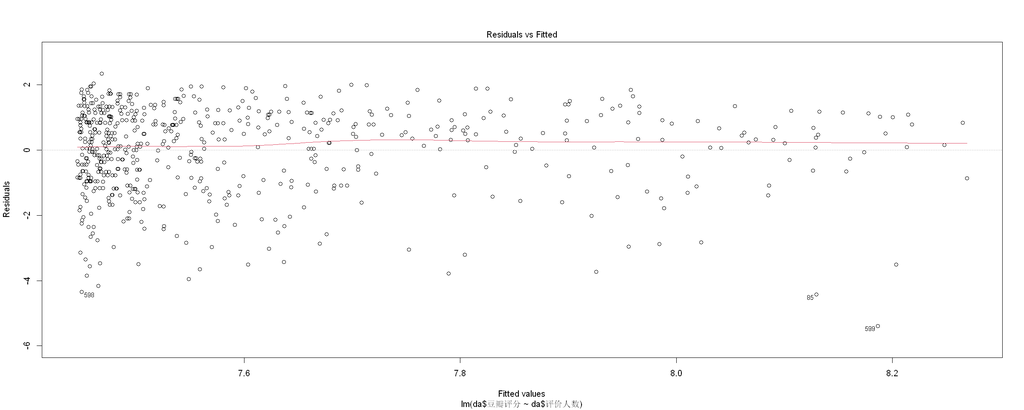

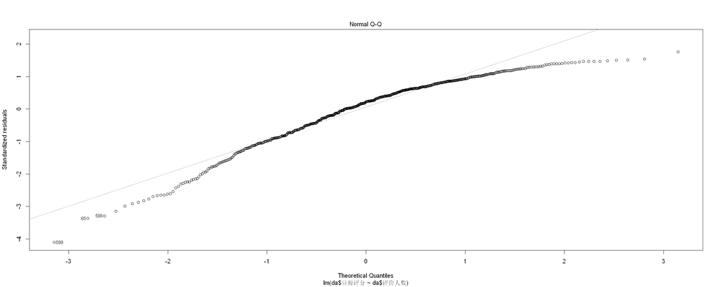

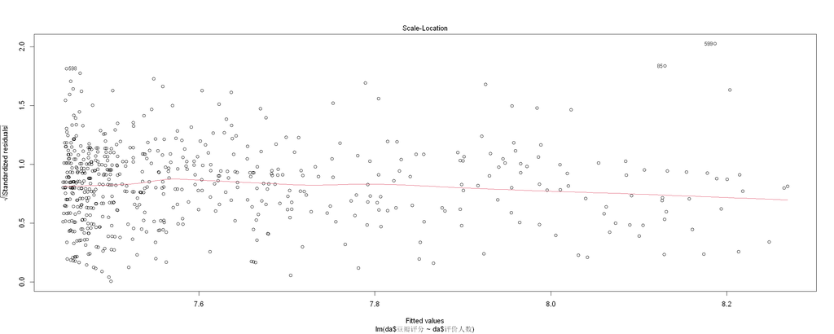

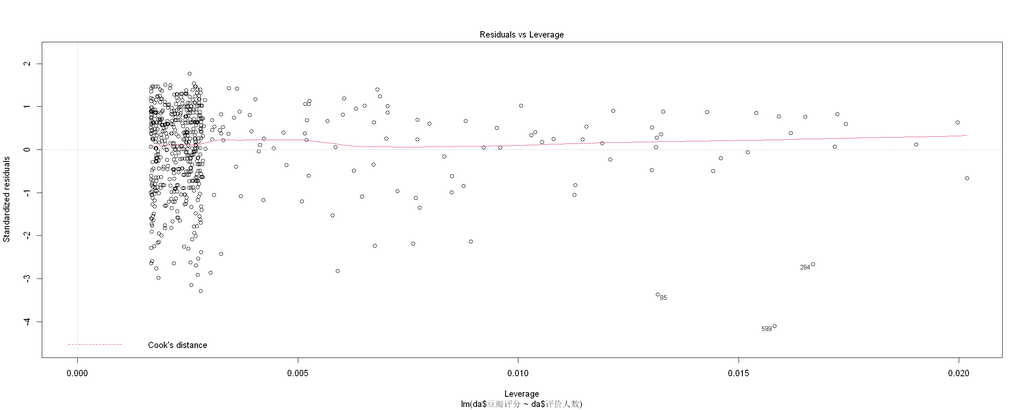

```r
plot(l)
```

- 回归诊断结果表明，除正态性稍差、存在部分异常值的cook距离较大之外，线性回归模型是较为可靠的。

```r
m<-lm(da$豆瓣评分*100~da$总时长)
summary(m)
```

```
Call:
lm(formula = da$豆瓣评分 * 100 ~ da$总时长)

Residuals:
    Min      1Q  Median      3Q     Max
-447.23  -84.82   26.92   87.10  351.35

Coefficients:
              Estimate Std. Error t value Pr(>|t|)
(Intercept) 818.869668   7.651915  107.02   <2e-16 ***
da$总时长    -0.095453   0.009497  -10.05   <2e-16 ***
---
Signif. codes:  0 '***' 0.001 '**' 0.01 '*' 0.05 '.' 0.1 ' ' 1

Residual standard error: 123.9 on 598 degrees of freedom
Multiple R-squared:  0.1445,	Adjusted R-squared:  0.1431
F-statistic:   101 on 1 and 598 DF,  p-value: < 2.2e-16
```

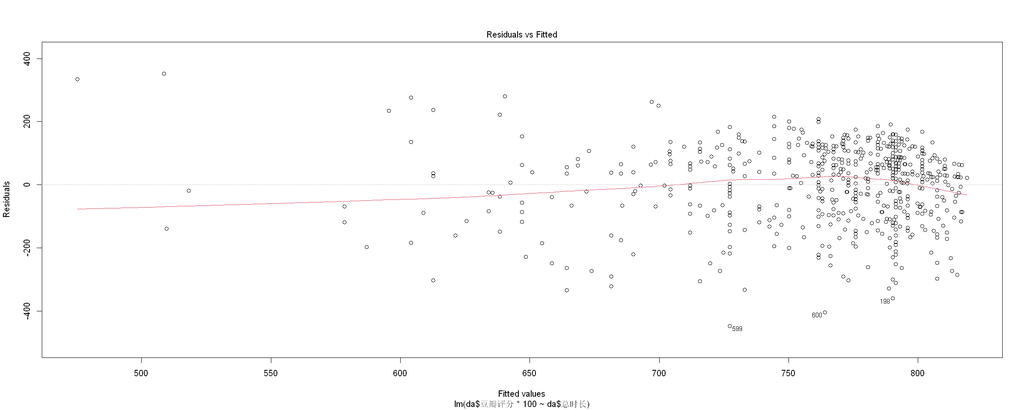

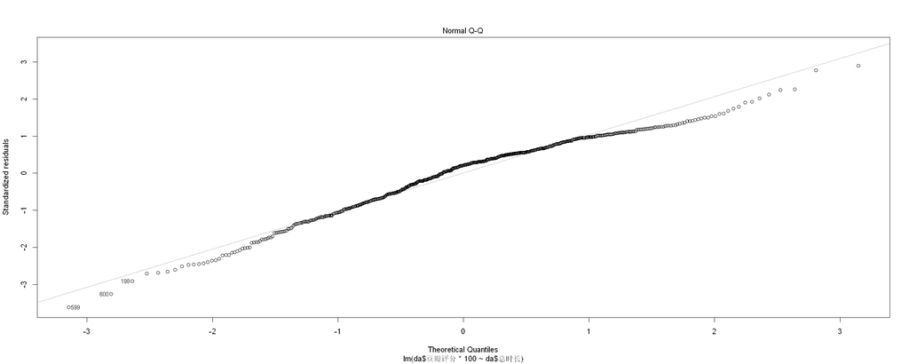

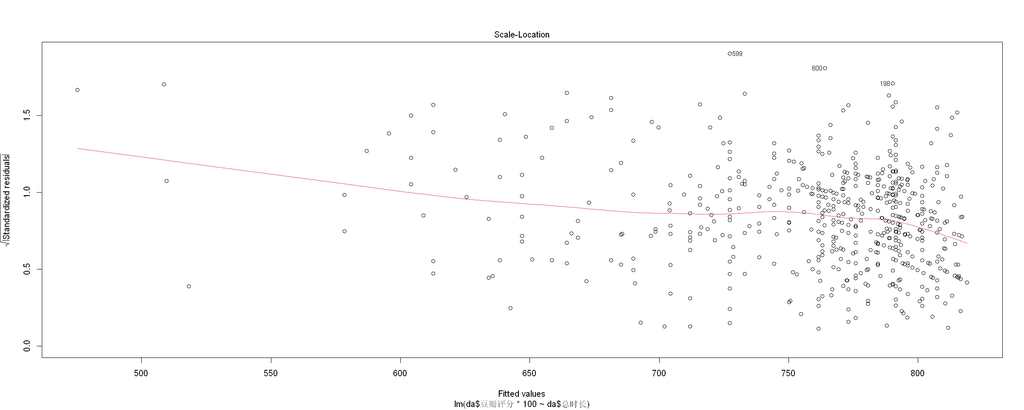

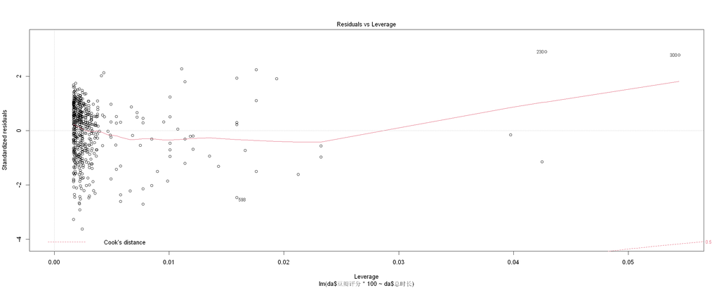

```r
plot(m)
```

- 回归诊断结果表明，除正态性稍差、存在部分异常值的cook距离较大之外，线性回归模型是较为可靠的。

```r
le<-lm(da$豆瓣评分~as.factor(da$类型))
summary(le)
```

```
Call:
lm(formula = da$豆瓣评分 ~ as.factor(da$类型))

Residuals:
    Min      1Q  Median      3Q     Max
-4.5606 -0.8384  0.2616  0.9616  2.4394

Coefficients:
                       Estimate Std. Error t value Pr(>|t|)
(Intercept)              8.7474     0.2115  41.350  < 2e-16 ***
as.factor(da$类型)剧情  -1.2089     0.2225  -5.434 8.03e-08 ***
as.factor(da$类型)其他  -1.3868     0.2457  -5.645 2.56e-08 ***
as.factor(da$类型)喜剧  -1.0250     0.2507  -4.089 4.93e-05 ***
---
Signif. codes:  0 '***' 0.001 '**' 0.01 '*' 0.05 '.' 0.1 ' ' 1

Residual standard error: 1.304 on 596 degrees of freedom
Multiple R-squared:  0.05498,	Adjusted R-squared:  0.05022
F-statistic: 11.56 on 3 and 596 DF,  p-value: 2.259e-07
```

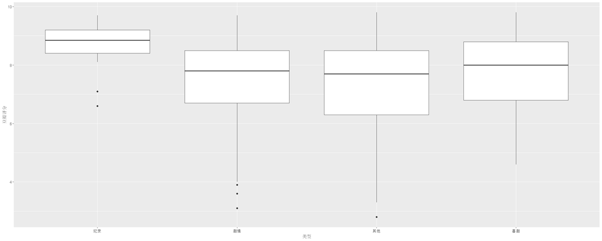

```r
ggplot(da, aes(x=类型, y=豆瓣评分)) + geom_boxplot()
```

- 作为因子的回归分析和箱线图共同表明，一方面评分和剧集类型存在显著的线性相关关系，另一方面四种剧集类型的均值存在明显的差异，尤其是纪录片显然高于其他种类剧集

```r
ll<-le<-lm(da$豆瓣评分~as.factor(da$语言))
summary(ll)
```

```
Call:
lm(formula = da$豆瓣评分 ~ as.factor(da$语言))

Residuals:
    Min      1Q  Median      3Q     Max
-4.0151 -0.7658  0.1342  0.9297  2.4849

Coefficients:
                       Estimate Std. Error t value Pr(>|t|)
(Intercept)             6.81506    0.09427  72.296  < 2e-16 ***
as.factor(da$语言)其他  0.95941    0.20068   4.781 2.20e-06 ***
as.factor(da$语言)日语  0.75521    0.12984   5.816 9.82e-09 ***
as.factor(da$语言)英语  1.45078    0.12723  11.403  < 2e-16 ***
---
Signif. codes:  0 '***' 0.001 '**' 0.01 '*' 0.05 '.' 0.1 ' ' 1

Residual standard error: 1.215 on 596 degrees of freedom
Multiple R-squared:  0.1803,	Adjusted R-squared:  0.1762
F-statistic: 43.69 on 3 and 596 DF,  p-value: < 2.2e-16
```

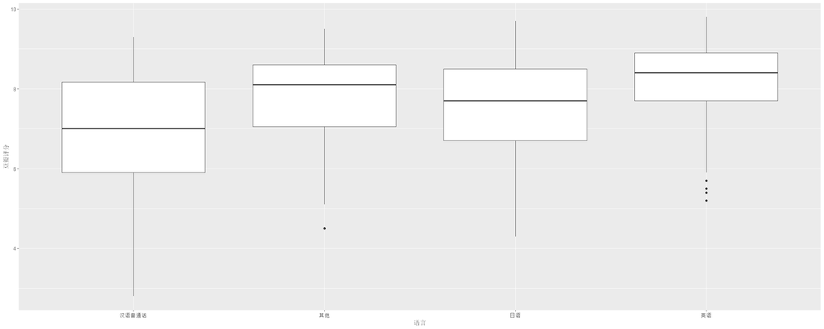

```r
ggplot(da, aes(x=语言, y=豆瓣评分)) + geom_boxplot()
```

- 作为因子的回归分析和箱线图共同表明，一方面剧集的语言对豆瓣评分有着显著的影响，另一方面不同语言的评分均值存在明显的差异，英语片的平均分数显著高于普通话

## (2)ANOVA分析和回归分析

```r
fit<-lm(da$豆瓣评分~as.factor(da$类型)+da$评价人数+as.factor(da$语言)+da$总时长)
summary(fit)
```

```
Call:
lm(formula = da$豆瓣评分 ~ as.factor(da$类型) + da$评价人数 +
    as.factor(da$语言) + da$总时长)

Residuals:
    Min      1Q  Median      3Q     Max
-4.5941 -0.7471  0.1026  0.7722  3.6293

Coefficients:
                         Estimate Std. Error t value Pr(>|t|)
(Intercept)             8.152e+00  2.040e-01  39.964  < 2e-16 ***
as.factor(da$类型)剧情 -9.907e-01  1.975e-01  -5.016 7.00e-07 ***
as.factor(da$类型)其他 -1.193e+00  2.191e-01  -5.444 7.66e-08 ***
as.factor(da$类型)喜剧 -9.803e-01  2.168e-01  -4.521 7.44e-06 ***
da$评价人数             9.279e-05  1.461e-05   6.349 4.32e-10 ***
as.factor(da$语言)其他  9.692e-01  1.860e-01   5.211 2.60e-07 ***
as.factor(da$语言)日语  4.900e-01  1.369e-01   3.578 0.000375 ***
as.factor(da$语言)英语  1.086e+00  1.293e-01   8.398 3.38e-16 ***
da$总时长              -6.937e-04  1.023e-04  -6.778 2.95e-11 ***
---
Signif. codes:  0 '***' 0.001 '**' 0.01 '*' 0.05 '.' 0.1 ' ' 1

Residual standard error: 1.111 on 591 degrees of freedom
Multiple R-squared:  0.3196,	Adjusted R-squared:  0.3104
F-statistic: 34.71 on 8 and 591 DF,  p-value: < 2.2e-16
```

```r
Anova(fit,type='III')
```

A anova: 6 × 4

|  | Sum Sq <dbl> | Df <dbl> | F value <dbl> | Pr(>F) <dbl> |
| --- | --- | --- | --- | --- |
| (Intercept) | 1971.86231 | 1 | 1597.11210 | 3.959155e-170 |
| as.factor(da$类型) | 37.80491 | 3 | 10.20671 | 1.463767e-06 |
| da$评价人数 | 49.76976 | 1 | 40.31107 | 4.319180e-10 |
| as.factor(da$语言) | 101.16321 | 3 | 27.31242 | 1.492249e-16 |
| da$总时长 | 56.72885 | 1 | 45.94759 | 2.947011e-11 |
| Residuals | 729.67366 | 591 | NA | NA |

- Anova分析显示选用的因素都较为重要
- 用AIC和BIC选择参数

```r
lm.aic=step(fit,trace=F)
summary(lm.aic)
lm.bic=step(fit,k=log(100),trace=F)
summary(lm.bic)
```

```
Call:
lm(formula = da$豆瓣评分 ~ as.factor(da$类型) + da$评价人数 +
    as.factor(da$语言) + da$总时长)

Residuals:
    Min      1Q  Median      3Q     Max
-4.5941 -0.7471  0.1026  0.7722  3.6293

Coefficients:
                         Estimate Std. Error t value Pr(>|t|)
(Intercept)             8.152e+00  2.040e-01  39.964  < 2e-16 ***
as.factor(da$类型)剧情 -9.907e-01  1.975e-01  -5.016 7.00e-07 ***
as.factor(da$类型)其他 -1.193e+00  2.191e-01  -5.444 7.66e-08 ***
as.factor(da$类型)喜剧 -9.803e-01  2.168e-01  -4.521 7.44e-06 ***
da$评价人数             9.279e-05  1.461e-05   6.349 4.32e-10 ***
as.factor(da$语言)其他  9.692e-01  1.860e-01   5.211 2.60e-07 ***
as.factor(da$语言)日语  4.900e-01  1.369e-01   3.578 0.000375 ***
as.factor(da$语言)英语  1.086e+00  1.293e-01   8.398 3.38e-16 ***
da$总时长              -6.937e-04  1.023e-04  -6.778 2.95e-11 ***
---
Signif. codes:  0 '***' 0.001 '**' 0.01 '*' 0.05 '.' 0.1 ' ' 1

Residual standard error: 1.111 on 591 degrees of freedom
Multiple R-squared:  0.3196,	Adjusted R-squared:  0.3104
F-statistic: 34.71 on 8 and 591 DF,  p-value: < 2.2e-16
```

```
Call:
lm(formula = da$豆瓣评分 ~ as.factor(da$类型) + da$评价人数 +
    as.factor(da$语言) + da$总时长)

Residuals:
    Min      1Q  Median      3Q     Max
-4.5941 -0.7471  0.1026  0.7722  3.6293

Coefficients:
                         Estimate Std. Error t value Pr(>|t|)
(Intercept)             8.152e+00  2.040e-01  39.964  < 2e-16 ***
as.factor(da$类型)剧情 -9.907e-01  1.975e-01  -5.016 7.00e-07 ***
as.factor(da$类型)其他 -1.193e+00  2.191e-01  -5.444 7.66e-08 ***
as.factor(da$类型)喜剧 -9.803e-01  2.168e-01  -4.521 7.44e-06 ***
da$评价人数             9.279e-05  1.461e-05   6.349 4.32e-10 ***
as.factor(da$语言)其他  9.692e-01  1.860e-01   5.211 2.60e-07 ***
as.factor(da$语言)日语  4.900e-01  1.369e-01   3.578 0.000375 ***
as.factor(da$语言)英语  1.086e+00  1.293e-01   8.398 3.38e-16 ***
da$总时长              -6.937e-04  1.023e-04  -6.778 2.95e-11 ***
---
Signif. codes:  0 '***' 0.001 '**' 0.01 '*' 0.05 '.' 0.1 ' ' 1

Residual standard error: 1.111 on 591 degrees of freedom
Multiple R-squared:  0.3196,	Adjusted R-squared:  0.3104
F-statistic: 34.71 on 8 and 591 DF,  p-value: < 2.2e-16
```

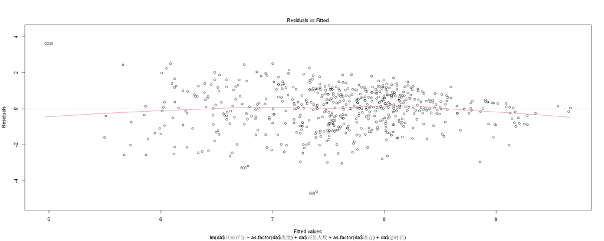

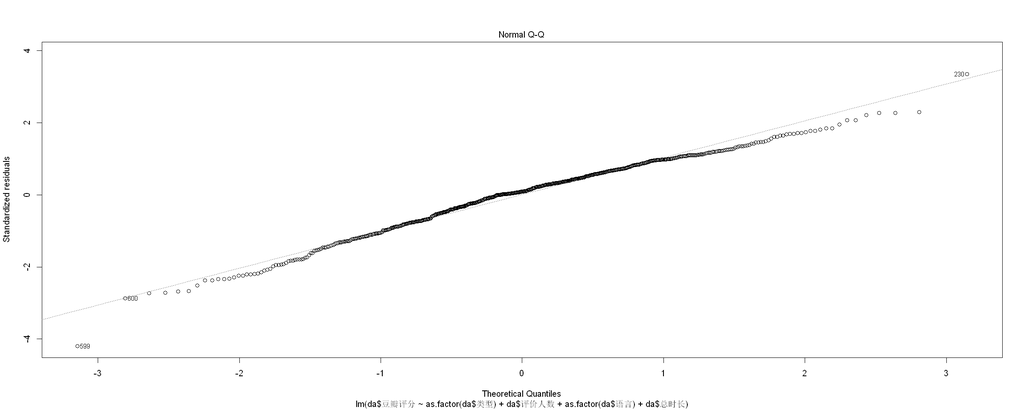

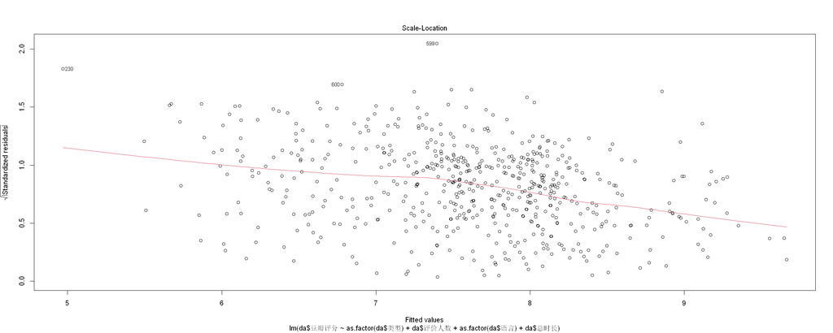

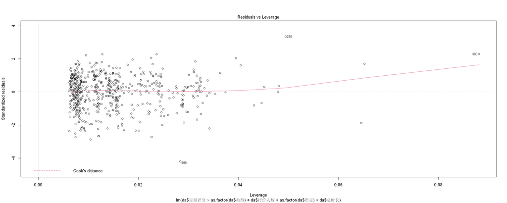

```r
plot(fit)
```

- A:  
  纪录 0  
  剧情 -0.9907  
  其他 -1.193  
  喜剧 -0.9803
- B:  
  汉语普通话 0  
  其他 0.9692  
  日语 0.4900  
  英语 1.086